# Data Management Template

Alan T. Arnholt

February 22, 2015

### Purpose of Study: (Note: This is the last paragraph of the research proposal used to remind the reader of the research objectives.)

The present study will examine young adults from the National Epidemiologic Survey of Alcohol and Related Conditions (NESARC). The goals of the analysis will include 1) establishing the relationship between major depression and nicotine dependence; and 2) determining whether or not the relationship between major depression and nicotine dependence exists above and beyond smoking quantity.

### Variables:

Variables from NESARC that will be used include: `MAJORDEPLIFE` (has subject experienced a major depression?), `CHECK321` (has subject smoked cigarettes in past 12 months?), `AGE` (age of subject), `TAB12MDX` (tobacco dependence past 12 months), `S3AQ3B1` (usual frequency when cigarettes smoked), `ETHRACE2A` (ethnicity of subject), `SEX` (gender of subject), and `S3AQ3C1` (usual smoking quantity of cigarettes when smoked). ￼

### Data Management

First, the data is placed on the search path using the `PDS` package. Next, a subset of people 25 or younger who smoked in the last 12 months is created using the `filter` function from `dplyr`. Note that `CHECK321 == 1` is used to see if subject has smoked in the past 12 months and `!is.na()` is used to make sure the subset does not contain `NA`s for the chosen variables. Last, the variables of interest are selected and stored in the data frame `nesarc.sub` using the `select` function from the `dplyr` package.

```r
library(PDS)
library(dplyr)
nesarc.sub <- NESARC %>%
  filter(!is.na(CHECK321) & !is.na(AGE) & CHECK321 ==1 & AGE <= 25)
dim(nesarc.sub)
```

```
[1] 1706 3008
```

```r
nesarc.sub <- nesarc.sub %>%
  select(MAJORDEPLIFE, CHECK321, AGE, TAB12MDX, S3AQ3B1, S3AQ3C1, ETHRACE2A, SEX)
dim(nesarc.sub)
```

```
[1] 1706    8
```

```r
summary(nesarc.sub)
```

```
 MAJORDEPLIFE CHECK321      AGE        TAB12MDX S3AQ3B1     S3AQ3C1
 0:1260       1:1706   Min.   :18.00   0:810    1:1320   Min.   : 1.0
 1: 446       2:   0   1st Qu.:20.00   1:896    2:  68   1st Qu.: 5.0
              9:   0   Median :22.00            3:  91   Median :10.0
                       Mean   :21.61            4:  88   Mean   :11.8
                       3rd Qu.:23.00            5:  65   3rd Qu.:20.0
                       Max.   :25.00            6:  71   Max.   :99.0
                                                9:   3
 ETHRACE2A SEX
 1:1060    1:856
 2: 211    2:850
 3:  42
 4:  58
 5: 335
```

Running `summary` on the `nesarc.sub` reveals some non-obvious categories for the factors `CHECK321` and `S3AQ3B1`. Reviewing the Code Book (HINT: Inside a pdf use `shift F` (Windows) or `command F` (Mac) then type the variable name inside the box to find the variable in the pdf), it is noted that a 9 is used to indicate missing values for `S3AQ3B1` and a 99 is used to indicate missing values for `S3AQ3C1`.

### Coding missing values

The variable `S3AQ3B1` uses a 9 to record `unknown` for smoking frequency and a 99 is used to record `unknown` for `S3AQ3C1`.

```r
nesarc.sub$S3AQ3B1[nesarc.sub$S3AQ3B1 == 9] <- NA
summary(nesarc.sub$S3AQ3B1)  # Note that 9 still appears
```

```
   1    2    3    4    5    6    9 NA's
1320   68   91   88   65   71    0    3
```

```r
nesarc.sub$S3AQ3B1 <- factor(nesarc.sub$S3AQ3B1)[, drop = TRUE]
summary(nesarc.sub$S3AQ3B1)  # Unused level no longer appears
```

```
   1    2    3    4    5    6 NA's
1320   68   91   88   65   71    3
```

```r
nesarc.sub$S3AQ3C1[nesarc.sub$S3AQ3C1 == 99] <- NA
summary(nesarc.sub$S3AQ3C1)
```

```
   Min. 1st Qu.  Median    Mean 3rd Qu.    Max.    NA's
   1.00    5.00   10.00   11.34   20.00   98.00       9
```

```r
nesarc.sub$CHECK321[nesarc.sub$CHECK321 == 9] <- NA
nesarc.sub$CHECK321 <- factor(nesarc.sub$CHECK321)[ , drop = TRUE]
summary(nesarc.sub)
```

```
 MAJORDEPLIFE CHECK321      AGE        TAB12MDX S3AQ3B1
 0:1260       1:1706   Min.   :18.00   0:810    1   :1320
 1: 446                1st Qu.:20.00   1:896    2   :  68
                       Median :22.00            3   :  91
                       Mean   :21.61            4   :  88
                       3rd Qu.:23.00            5   :  65
                       Max.   :25.00            6   :  71
                                                NA's:   3
    S3AQ3C1      ETHRACE2A SEX
 Min.   : 1.00   1:1060    1:856
 1st Qu.: 5.00   2: 211    2:850
 Median :10.00   3:  42
 Mean   :11.34   4:  58
 3rd Qu.:20.00   5: 335
 Max.   :98.00
 NA's   :9
```

### Creating New Variables

```r
nesarc.sub$DaysSmoke <- as.numeric(nesarc.sub$S3AQ3B1)
nesarc.sub$DaysSmoke[nesarc.sub$DaysSmoke == 1] <- 30
nesarc.sub$DaysSmoke[nesarc.sub$DaysSmoke == 2] <- 4*5.5
nesarc.sub$DaysSmoke[nesarc.sub$DaysSmoke == 3] <- 4*3.5
nesarc.sub$DaysSmoke[nesarc.sub$DaysSmoke == 4] <- 4*1.5
nesarc.sub$DaysSmoke[nesarc.sub$DaysSmoke == 5] <- 2.5
nesarc.sub$DaysSmoke[nesarc.sub$DaysSmoke == 6] <- 1
# Using dplyr again
nesarc.sub <- nesarc.sub %>%
  mutate(TotalCigsSmoked = DaysSmoke*S3AQ3C1)
proportions <- quantile(nesarc.sub$TotalCigsSmoked, na.rm = TRUE)
proportions
```

```
  0%  25%  50%  75% 100%
   1   90  300  600 2940
```

```r
nesarc.sub$CigsSmokedFac <- cut(nesarc.sub$TotalCigsSmoked, breaks = proportions, include.lowest = TRUE)
head(nesarc.sub)
```

```
  MAJORDEPLIFE CHECK321 AGE TAB12MDX S3AQ3B1 S3AQ3C1 ETHRACE2A SEX
1            0        1  25        1       1       3         2   2
2            1        1  21        1       2       3         5   1
3            1        1  24        1       1      10         1   2
4            1        1  23        1       1      10         1   2
5            0        1  21        0       1      20         1   1
6            1        1  23        0       1       5         1   2
  DaysSmoke TotalCigsSmoked CigsSmokedFac
1        30              90        [1,90]
2        22              66        [1,90]
3        30             300      (90,300]
4        30             300      (90,300]
5        30             600     (300,600]
6        30             150      (90,300]
```

### Labeling Variables

In the next section of code, variables are labeled and levels of factors are given informative labels. The order of the levels is also rearranged for the variables `S3AQ3B1`, `TAB12MDX`, and `SEX`.

```r
library(Hmisc)
label(nesarc.sub$TAB12MDX) <- "Tobacco Dependence past 12 Months"
label(nesarc.sub$CHECK321) <- "Smoked Cigarettes in the Past 12 Months"
label(nesarc.sub$S3AQ3B1) <- "Usual Smoking Frequency"
label(nesarc.sub$S3AQ3C1) <- "Usual Smoking Quantity"
nesarc.sub$MAJORDEPLIFE <- factor(nesarc.sub$MAJORDEPLIFE,
                              labels = c("No Depression", "Yes Depression"))
nesarc.sub$S3AQ3B1 <- factor(nesarc.sub$S3AQ3B1,
                         labels = c("Every Day", "5 to 6 Days/week",
                                    "3 to 4 Days/week",   "1 to 2 Days/week", "2 to 3 Days/month",
                                    "Once a month or less"))
nesarc.sub$S3AQ3B1 <- factor(nesarc.sub$S3AQ3B1,
                         levels = c("Once a month or less", "2 to 3 Days/month", "1 to 2 Days/week",  "3 to 4 Days/week", "5 to 6 Days/week", "Every Day"))
nesarc.sub$TAB12MDX <- factor(nesarc.sub$TAB12MDX,
                         labels = c("No Nicotine Dependence", "Nicotine Dependence"))
nesarc.sub$TAB12MDX <- factor(nesarc.sub$TAB12MDX,
                         levels = c("Nicotine Dependence", "No Nicotine Dependence"))
nesarc.sub$ETHRACE2A <- factor(nesarc.sub$ETHRACE2A, labels = c("Caucasian", "African American", "Native American", "Asian", "Hispanic"))
nesarc.sub$SEX <- factor(nesarc.sub$SEX, labels = c("Male", "Female"))
table(nesarc.sub$SEX)
```

```
  Male Female
   856    850
```

```r
nesarc.sub$SEX <- factor(nesarc.sub$SEX, levels = c("Female", "Male"))
summary(nesarc.sub)
```

```
         MAJORDEPLIFE  CHECK321      AGE
 No Depression :1260   1:1706   Min.   :18.00
 Yes Depression: 446            1st Qu.:20.00
                                Median :22.00
                                Mean   :21.61
                                3rd Qu.:23.00
                                Max.   :25.00

                   TAB12MDX                   S3AQ3B1        S3AQ3C1
 Nicotine Dependence   :896   Once a month or less:  71   Min.   : 1.00
 No Nicotine Dependence:810   2 to 3 Days/month   :  65   1st Qu.: 5.00
                              1 to 2 Days/week    :  88   Median :10.00
                              3 to 4 Days/week    :  91   Mean   :11.34
                              5 to 6 Days/week    :  68   3rd Qu.:20.00
                              Every Day           :1320   Max.   :98.00
                              NA's                :   3   NA's   :9
            ETHRACE2A        SEX        DaysSmoke     TotalCigsSmoked
 Caucasian       :1060   Female:850   Min.   : 1.00   Min.   :   1.0
 African American: 211   Male  :856   1st Qu.:30.00   1st Qu.:  90.0
 Native American :  42                Median :30.00   Median : 300.0
 Asian           :  58                Mean   :25.07   Mean   : 319.4
 Hispanic        : 335                3rd Qu.:30.00   3rd Qu.: 600.0
                                      Max.   :30.00   Max.   :2940.0
                                      NA's   :3       NA's   :9
        CigsSmokedFac
 [1,90]        :429
 (90,300]      :678
 (300,600]     :503
 (600,2.94e+03]: 87
 NA's          :  9
```

### Renaming Variables

```r
nesarc.sub <- nesarc.sub %>%
  rename(Depression = MAJORDEPLIFE, TobaccoDependence = TAB12MDX, SmokingFreq = S3AQ3B1, DailyCigsSmoked = S3AQ3C1, Ethnicity = ETHRACE2A, Sex = SEX, Age = AGE)
head(nesarc.sub)
```

```
      Depression CHECK321 Age      TobaccoDependence      SmokingFreq
1  No Depression        1  25    Nicotine Dependence        Every Day
2 Yes Depression        1  21    Nicotine Dependence 5 to 6 Days/week
3 Yes Depression        1  24    Nicotine Dependence        Every Day
4 Yes Depression        1  23    Nicotine Dependence        Every Day
5  No Depression        1  21 No Nicotine Dependence        Every Day
6 Yes Depression        1  23 No Nicotine Dependence        Every Day
  DailyCigsSmoked        Ethnicity    Sex DaysSmoke TotalCigsSmoked
1               3 African American Female        30              90
2               3         Hispanic   Male        22              66
3              10        Caucasian Female        30             300
4              10        Caucasian Female        30             300
5              20        Caucasian   Male        30             600
6               5        Caucasian Female        30             150
  CigsSmokedFac
1        [1,90]
2        [1,90]
3      (90,300]
4      (90,300]
5     (300,600]
6      (90,300]
```

### Creating Tables

Basic tables can be created using the functions `table` or `xtabs`. Frequency tables are created for the variables `TobaccoDependence`, `CigsSmokedFac`, and `SmokingFreq`.

```r
T1 <- xtabs(~TobaccoDependence, data = nesarc.sub)
T2 <- xtabs(~CigsSmokedFac, data = nesarc.sub)
T3 <- xtabs(~SmokingFreq, data = nesarc.sub)
table(nesarc.sub$TobaccoDependence)
```

```
   Nicotine Dependence No Nicotine Dependence
                   896                    810
```

```r
T1
```

```
TobaccoDependence
   Nicotine Dependence No Nicotine Dependence
                   896                    810
```

```r
T2
```

```
CigsSmokedFac
        [1,90]       (90,300]      (300,600] (600,2.94e+03]
           429            678            503             87
```

```r
T3
```

```
SmokingFreq
Once a month or less    2 to 3 Days/month     1 to 2 Days/week
                  71                   65                   88
    3 to 4 Days/week     5 to 6 Days/week            Every Day
                  91                   68                 1320
```

In the data frame `nesarc.sub`, there are 896 nicotine dependent subjects and 810 subjects that are not nicotine dependent. A small number of smokers (87) smoke over 600 cigarettes per month. Most of the subjects in `nesarc.sub` are daily smokers (1320) with the remainder distributed uniformly across the first five levels of `SmokingFreq`.

### Graphing Frequency Tables

The barplots are all created with the package `ggplot2`. The barplots start with the defaults for the `geom_bar` and add more detail to the plot with each graph.

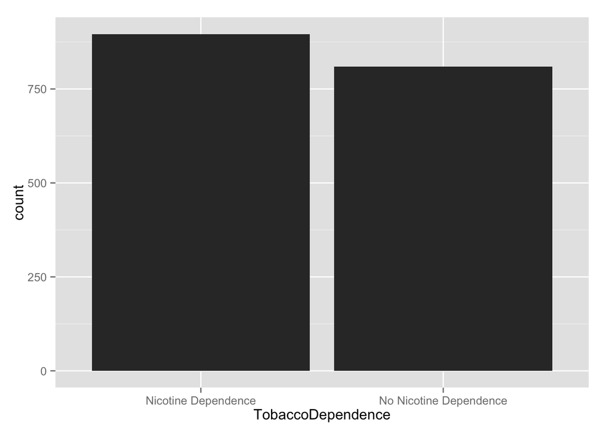

```r
library(ggplot2)
g1 <- ggplot(data = nesarc.sub, aes(x = TobaccoDependence)) +
  geom_bar()
g1
```

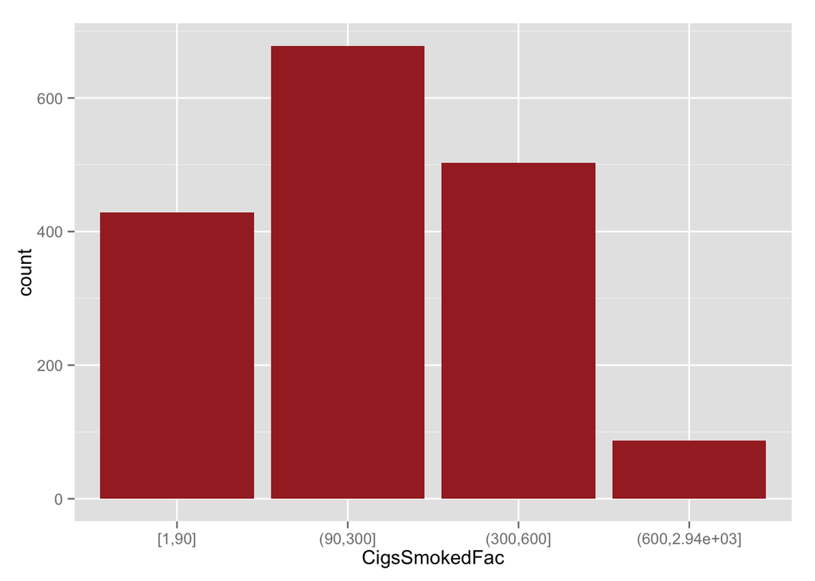

```r
g2 <- ggplot(data = na.omit(nesarc.sub), aes(x = CigsSmokedFac)) +
  geom_bar(fill = "brown")
g2
```

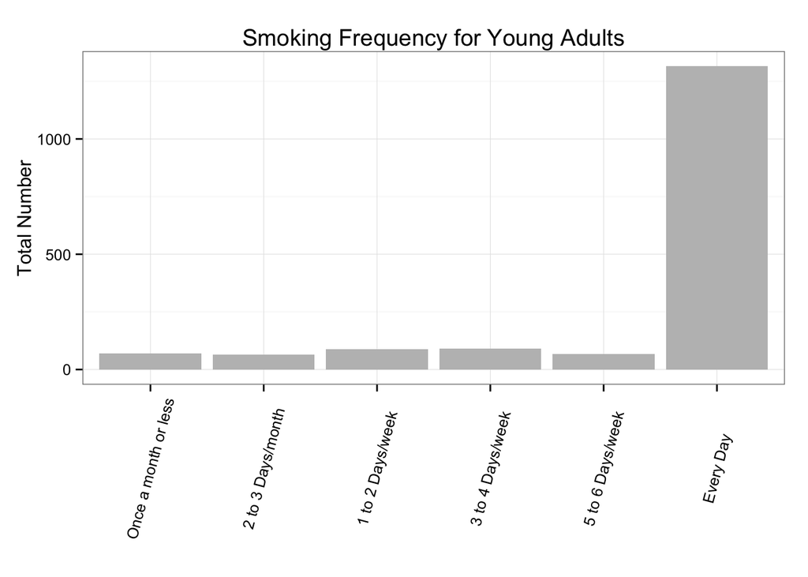

```r
g3 <- ggplot(data = na.omit(nesarc.sub), aes(SmokingFreq)) +
  geom_bar(fill = "gray") +
  labs(x = "", y = "Total Number", title = "Smoking Frequency for Young Adults") +
  theme_bw() +
  theme(axis.text.x  = element_text(angle = 75, vjust = 0.5))
g3
```

### Graphing Numeric Variables

One popular way to graph a continuous variable is to use a histogram. `R` has the base function `hist` which can be used for this purpose. We will also use the package `ggplot2` to create histograms. We start with a basic histogram of the variable `TotalCigsSmoked`.

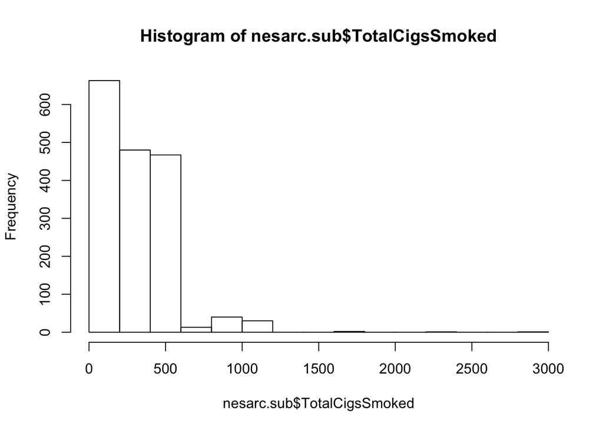

```r
hist(nesarc.sub$TotalCigsSmoked)
```

Experiment with the code in the previous code chunk to change the color, the title, and if needed the labels on the $x$- and $y$-axes.

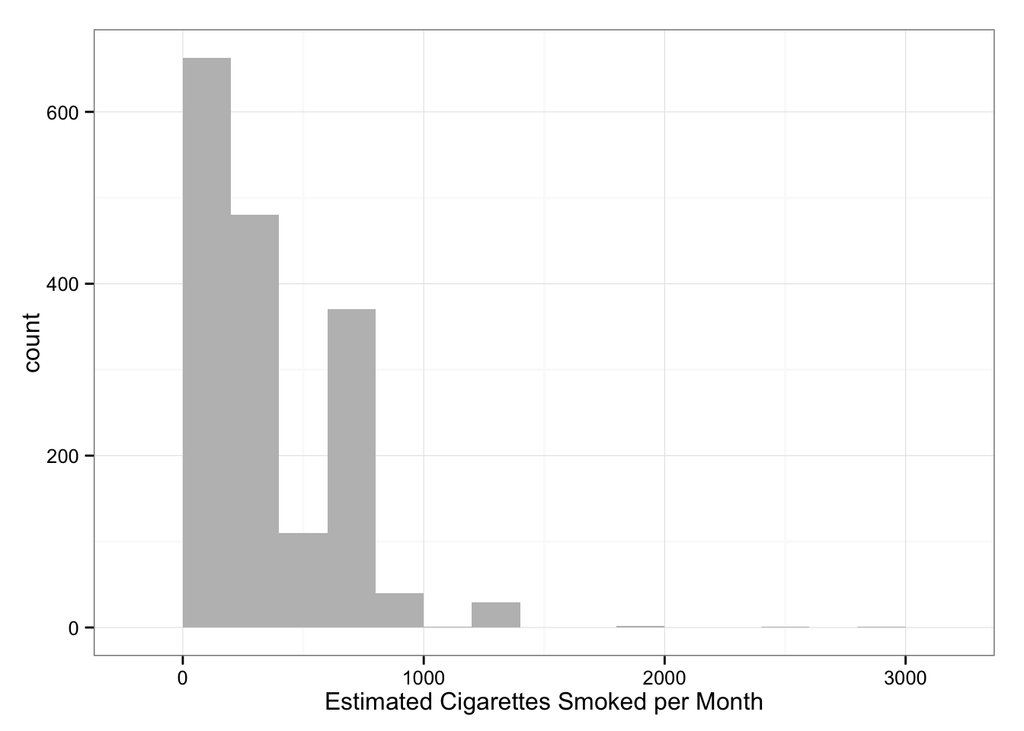

```r
ggplot(data = nesarc.sub, aes(x = TotalCigsSmoked)) +
  geom_histogram(binwidth = 200, fill = "gray") +
  labs(x = "Estimated Cigarettes Smoked per Month") +
  theme_bw()
```

### Creating Density Plots

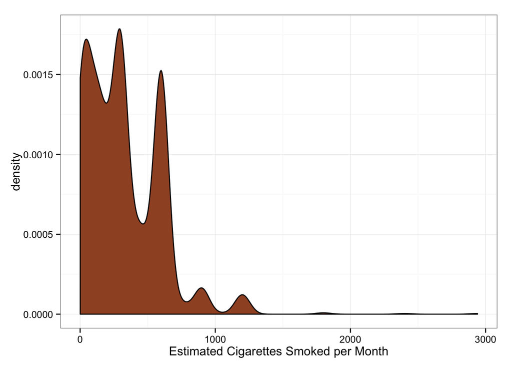

```r
ggplot(data = nesarc.sub, aes(x = TotalCigsSmoked)) +
  geom_density(fill = "sienna") +
  labs(x = "Estimated Cigarettes Smoked per Month") +
  theme_bw()
```

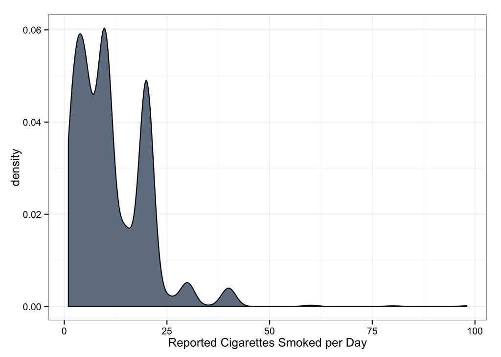

```r
ggplot(data = nesarc.sub, aes(x = DailyCigsSmoked)) +
  geom_density(fill = "slategrey") +
  labs(x = "Reported Cigarettes Smoked per Day") +
  theme_bw()
```

### The 3 S’s

```r
summary(nesarc.sub$TotalCigsSmoked)
```

```
   Min. 1st Qu.  Median    Mean 3rd Qu.    Max.    NA's
    1.0    90.0   300.0   319.4   600.0  2940.0       9
```

```r
fivenum(nesarc.sub$TotalCigsSmoked)
```

```
[1]    1   90  300  600 2940
```

```r
median(nesarc.sub$TotalCigsSmoked, na.rm = TRUE)
```

```
[1] 300
```

```r
IQR(nesarc.sub$TotalCigsSmoked, na.rm = TRUE)
```

```
[1] 510
```

The `shape` of the distribution for the estimated cigarettes smoked per month is skewed to the right. The `center` (median) of the distribution is 300 and the `spread` (interquartile range) for the distribution is 510.